# Spatial Data

WS 2016/2017

## Prerequisites

## setwd, library, data

```r
setwd("YOUR-PATH")
```

```r
raw_data <- read.table(file = "data/FS_UTM.csv",
                       header = TRUE,
                       sep = ";",
                       stringsAsFactors = FALSE,
                       quote = "")
```

## 4a. Check data structure

Do you remember the "4" issue from the previous session?! Let's check it again and solve the problem. I use a `(s)apply` way. You can chose the method you prefer.

First, let's check which columns have problems

```r
#str(raw_data)
#sapply(raw_data[,4:20], function(x){x[x>1]})
apply(X=raw_data[,4:20], MARGIN = 2, FUN=function(x){x[x>1]})
```

```
## $settlement
## [1] 4
##
## $open.settlement
## integer(0)
##
## $cave.settlement
## integer(0)
##
## $tell.settlement
## integer(0)
##
## $mound
## integer(0)
##
## $fortification
## integer(0)
##
## $court
## integer(0)
##
## $depot
## integer(0)
##
## $cult.complex
## integer(0)
##
## $mine
## integer(0)
##
## $chruch
## integer(0)
##
## $temple
## integer(0)
##
## $villa.rustica
## integer(0)
##
## $monastery
## integer(0)
##
## $cemetery
## integer(0)
##
## $necropolis
## integer(0)
##
## $tumulus
## integer(0)
```

## 4a. Check data structure

Now, let's solve the problem and check again

```r
raw_data$settlement[raw_data$settlement > 1] <- 1

sapply(raw_data[,4:20], function(x){x[x>1]})
```

```
## $settlement
## numeric(0)
##
## $open.settlement
## integer(0)
##
## $cave.settlement
## integer(0)
##
## $tell.settlement
## integer(0)
##
## $mound
## integer(0)
##
## $fortification
## integer(0)
##
## $court
## integer(0)
##
## $depot
## integer(0)
##
## $cult.complex
## integer(0)
##
## $mine
## integer(0)
##
## $chruch
## integer(0)
##
## $temple
## integer(0)
##
## $villa.rustica
## integer(0)
##
## $monastery
## integer(0)
##
## $cemetery
## integer(0)
##
## $necropolis
## integer(0)
##
## $tumulus
## integer(0)
```

## 4b. Check data structure

So, now it's time to have a look at the coordinates…

```r
#str(raw_data)
raw_data[c(1:6),c(2,35,36)]
```

```
##                          Site.Name     xUTM    yUTM
## 1        Beba Veche - in the ditch 443157.0 5105906
## 2 Dudestii Vechi - Dragomirs' hill 459881.7 5095991
## 3               Nerau - Hunca Mare 462115.2 5088415
## 4             Nerau - Dogans' hill 466750.8 5089685
## 5          Cenad - Habitation Area 467929.9 5109462
## 6          Nerau - The south canal 468829.2 5092020
```

**Question:** Is there another way to create this overview?

## 4b. Check data structure

Yes.

```r
#str(raw_data)
head(raw_data[,c(2,35,36)])
```

```
##                          Site.Name     xUTM    yUTM
## 1        Beba Veche - in the ditch 443157.0 5105906
## 2 Dudestii Vechi - Dragomirs' hill 459881.7 5095991
## 3               Nerau - Hunca Mare 462115.2 5088415
## 4             Nerau - Dogans' hill 466750.8 5089685
## 5          Cenad - Habitation Area 467929.9 5109462
## 6          Nerau - The south canal 468829.2 5092020
```

## Create a spatial object

## Some useful references

- THE book that covers a broad range of topics:
- Bivand, Roger S., Edzer J. Pebesma, and Virgilio Gómez-Rubio. 2008. Applied Spatial Data Analysis with R. New York: Springer.
- Useful tutorial-like introduction in the handling and plotting of spatial data
- Lovelace, Robin, and James Cheshire. 2015. “Introduction to Visualising Spatial Data in R.” [link](https://github.com/Robinlovelace/Creating-maps-in-R/raw/master/intro-spatial-rl.pdf).

## Spatial data libraries

```r
library(sp)
library(rgdal)
```

- sp: Classes and Methods for Spatial Data
- https://cran.r-project.org/web/packages/sp/index.html
- rgdal: Bindings for the Geospatial Data Abstraction Library
- based on GDAL "Swiss Army Knife for Geospatial Data" -> https://gdal.org
- https://cran.r-project.org/web/packages/rgdal/index.html

## Create spatial object

As always there are numerous ways to accomplish this. See https://cran.r-project.org/web/packages/sp/vignettes/intro_sp.pdf

There are some things we need to know in advance:

1. What kind of spatial data do we have?
2. What are the coordinates?
3. What is the reference system?
- Your best friend: https://www.epsg.io

## Create spatial data

```r
sites <- SpatialPointsDataFrame(coords = cbind(raw_data$xUTM,raw_data$yUTM),
                                data = data.frame(raw_data[,2]),
                                proj4string = CRS("+init=epsg:32634")
                                )
class(sites)
```

```
## [1] "SpatialPointsDataFrame"
## attr(,"package")
## [1] "sp"
```

**Exercise:** Find other ways to create a spatial data object.

## Create spatial data

```r
sites <- raw_data
coordinates(sites) <- ~xUTM+yUTM
class(sites)
```

```
## [1] "SpatialPointsDataFrame"
## attr(,"package")
## [1] "sp"
```

**Exercise:** Check the `str`ucture of the `sites` object. What is missing?

```r
is.projected(sites)
```

```
## [1] NA
```

```r
proj4string(sites) <- CRS("+init=epsg:32634")
is.projected(sites)
```

```
## [1] TRUE
```

## Plot it

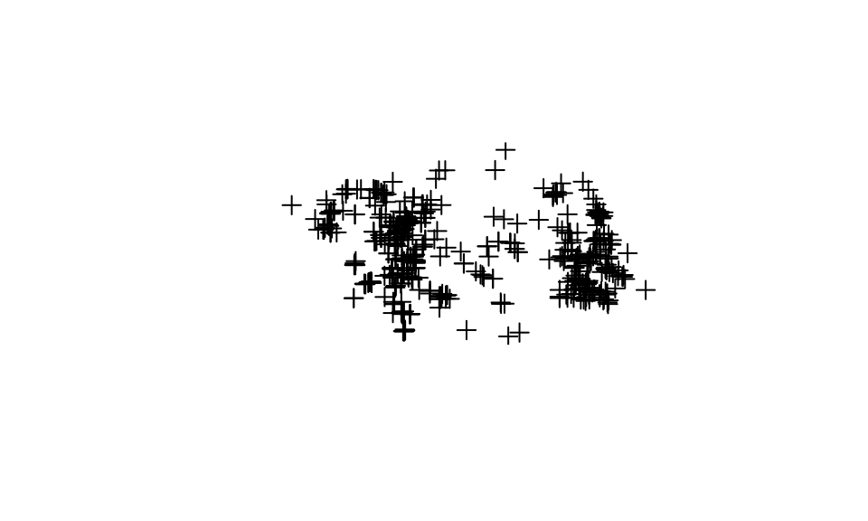

```r
plot(sites)
```

Find further ways to plot the points.

A collection of examples: https://pakillo.github.io/R-GIS-tutorial/

## Plot it 2.0

It's all about interaction, isn't it?

```r
library(magrittr)
library(leaflet)

sites <- spTransform(sites, "+init=epsg:4326")

m1 <- leaflet() %>%
    addProviderTiles("Thunderforest.Landscape") %>%
        addMarkers(lng=sites@coords[,1],
                   lat=sites@coords[,2],
                   popup = sites@data$Site.Name
                   )
m1
```

[interactive chart not shown]

## Plot it 2.0

You can also change the map tile provider for a wide range of different maps. An overview can be found here: http://leaflet-extras.github.io/leaflet-providers/preview/index.html

```r
library(magrittr)
library(leaflet)

sites <- spTransform(sites, "+init=epsg:4326")

m2 <- leaflet() %>%
    addProviderTiles("OpenStreetMap.HOT") %>%
        addMarkers(lng=sites@coords[,1],
                   lat=sites@coords[,2],
                   popup = sites@data$Site.Name
                   )
m2
```

[interactive chart not shown]

## Plot it 2.0

Another great package for interactive visualization: [mapview](http://environmentalinformatics-marburg.github.io/web-presentations/20150723_mapView.html)

**Question:** What is the drawback of these interactive mapping approaches?

## Export to Shapefile

```r
writeOGR(obj = sites,
         dsn = "data",
         layer = "A_Sites",
         driver = "ESRI Shapefile",
         overwrite_layer = TRUE
         )
list.files("./data")
```

```
## [1] "A_Sites.dbf"    "A_Sites.prj"    "A_Sites.shp"    "A_Sites.shx"
## [5] "FS_UTM.csv"     "FS_UTM.xlsx"    "srtm_41_03.tif"
```

## Export to graphics file

not very useful; just to show how easy it is

```r
png("data/A_Sites.png")
plot(sites)
dev.off()

## pdf, svg, postscript
?grDevices

?cairo
```